# Lecture 2 — GA4 BigQuery Analysis

Intermediate & Advanced SQL Patterns

Author

Lydia Chen

Published

March 1, 2026

# Query 1：CTEs — Total Users vs New Users

WITH UserInfo AS (  
SELECT  
user_pseudo_id,  
MAX(IF(event_name IN (‘first_visit’, ‘first_open’), 1, 0)) AS is_new_user  
FROM `bigquery-public-data.ga4_obfuscated_sample_ecommerce.events_*`  
WHERE _TABLE_SUFFIX BETWEEN ‘20201101’ AND ‘20201130’  
GROUP BY user_pseudo_id  
)  
SELECT  
COUNT(*) AS total_users,  
SUM(is_new_user) AS new_users  
FROM UserInfo;

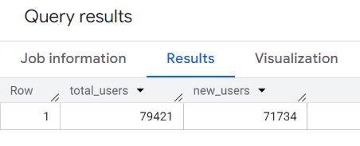

## Explanation

This query uses a Common Table Expression (CTE) to classify each user as either a new user or a returning user based on first_visit or first_open events. After identifying user types, the query aggregates the data to calculate the total number of users and how many of them are new within the selected time period.

# Query 2：Arrays + UNNEST（Pattern A：Scalar subquery）

SELECT  
TIMESTAMP_MICROS(event_timestamp) AS event_time,  
(  
SELECT value.string_value  
FROM UNNEST(event_params)  
WHERE key = ‘page_location’  
LIMIT 1  
) AS page_location  
FROM `bigquery-public-data.ga4_obfuscated_sample_ecommerce.events_*`  
WHERE event_name = ‘page_view’  
AND _TABLE_SUFFIX BETWEEN ‘20201201’ AND ‘20201202’  
LIMIT 50;

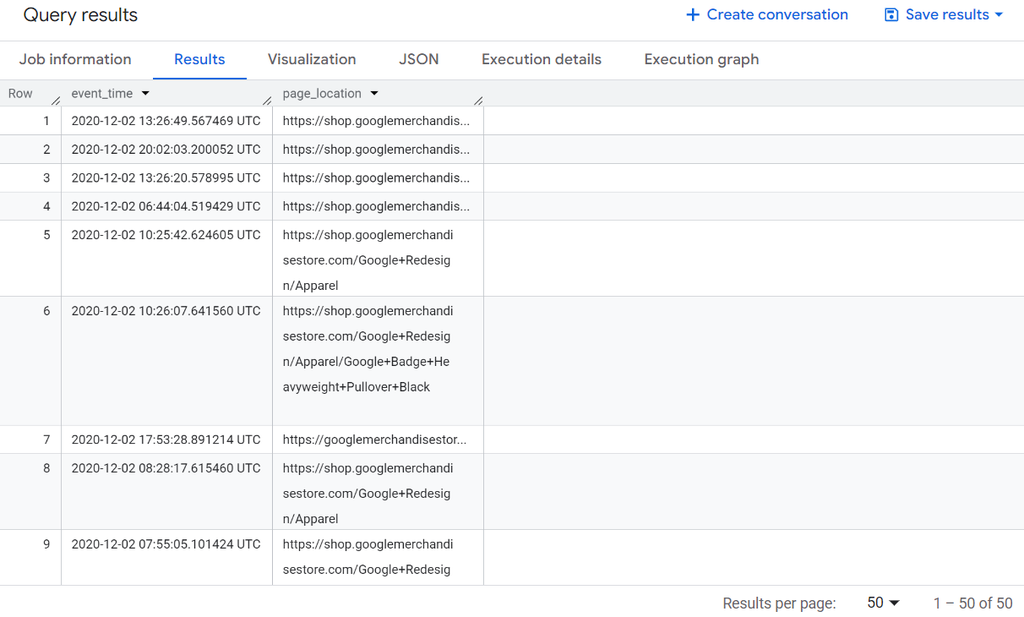

## Explanation

This query extracts the `page_location` parameter from the `event_params` array for page view events using a scalar subquery. This approach keeps the data at the event level without flattening the array, which helps avoid row duplication while retrieving the page URL associated with each event.

# Query 3：Arrays + UNNEST（Pattern B：Flatten items）

SELECT  
event_date,  
item.item_name,  
COUNT(*) AS item_rows  
FROM `bigquery-public-data.ga4_obfuscated_sample_ecommerce.events_*` e,  
UNNEST(e.items) AS item  
WHERE e.event_name = ‘purchase’  
AND _TABLE_SUFFIX BETWEEN ‘20201201’ AND ‘20201231’  
GROUP BY event_date, item.item_name  
ORDER BY item_rows DESC  
LIMIT 20;

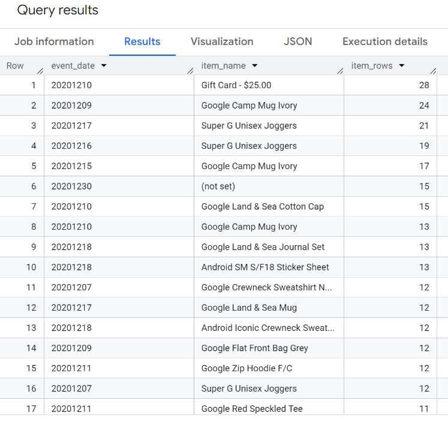

## Explanation

This query unnests the `items` array from purchase events to analyze data at the item level. By flattening the array, each row represents a single item within a purchase, allowing the query to count how frequently each item appears in purchase events.

# Query 4：STRING_AGG: Events Seen per Day

SELECT  
event_date,  
STRING_AGG(DISTINCT event_name, ‘,’ ORDER BY event_name) AS events_seen  
FROM `bigquery-public-data.ga4_obfuscated_sample_ecommerce.events_*`  
WHERE _TABLE_SUFFIX BETWEEN ‘20201201’ AND ‘20201203’  
GROUP BY event_date  
ORDER BY event_date;

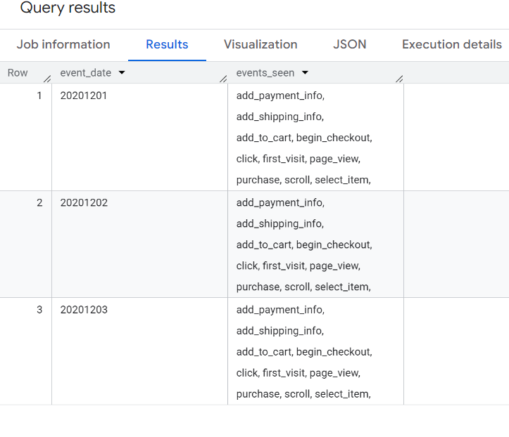

## Explanation

This query uses `STRING_AGG` to combine distinct event names into a single string for each day. It provides a quick overview of the types of events that occurred on each date without listing them as separate rows.

# Query 5：ARRAY_AGG: Items Added to Cart (User Level)

SELECT  
user_pseudo_id,  
ARRAY_AGG(item_name) AS items_added_to_cart  
FROM `bigquery-public-data.ga4_obfuscated_sample_ecommerce.events_*`,  
UNNEST(items) AS item  
WHERE event_name = ‘add_to_cart’  
AND _TABLE_SUFFIX BETWEEN ‘20201201’ AND ‘20201231’  
GROUP BY user_pseudo_id  
ORDER BY user_pseudo_id  
LIMIT 10;

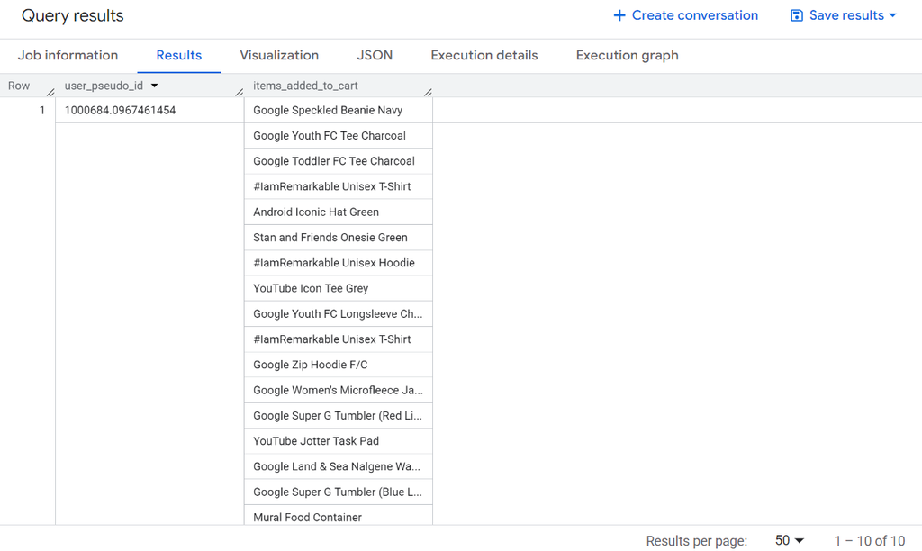

## Explanation

This query aggregates item names into an array for each user based on add-to-cart events. The result shows a list of items that each user added to their cart, summarizing multiple item-level actions into a single row per user.

# Query 6：ARRAY_AGG: Session-Level Cart Summary

WITH add_to_cart AS (  
SELECT  
user_pseudo_id,  
(  
SELECT value.int_value  
FROM UNNEST(event_params)  
WHERE key = ‘ga_session_id’  
) AS session_id,  
TIMESTAMP_MICROS(event_timestamp) AS event_timestamp,  
i.item_id,  
i.item_name,  
i.quantity,  
i.price  
FROM `bigquery-public-data.ga4_obfuscated_sample_ecommerce.events_*`,  
UNNEST(items) AS i  
WHERE event_name = ‘add_to_cart’  
AND _TABLE_SUFFIX BETWEEN ‘20210101’ AND ‘20211231’  
)  
SELECT  
user_pseudo_id,  
session_id,  
COUNT(*) AS total_add_to_cart_events,  
ARRAY_AGG(  
STRUCT(item_id, item_name, quantity, price, event_timestamp)  
ORDER BY quantity DESC, event_timestamp ASC  
LIMIT 10  
) AS cart_items  
FROM add_to_cart  
WHERE session_id IS NOT NULL  
GROUP BY user_pseudo_id, session_id;

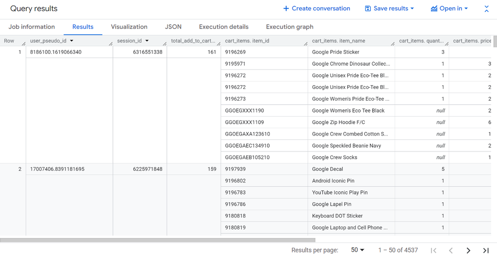

## Explanation

This query creates a session-level summary of add-to-cart activity by first extracting session IDs and item details using a CTE. It then aggregates item information into structured arrays, providing a detailed view of what items were added during each user session.

# Query 7：JOIN — Daily Users and Daily Purchases

WITH daily_users AS (  
SELECT  
event_date,  
COUNT(DISTINCT user_pseudo_id) AS users  
FROM `bigquery-public-data.ga4_obfuscated_sample_ecommerce.events_*`  
WHERE _TABLE_SUFFIX BETWEEN ‘20201201’ AND ‘20201231’  
GROUP BY event_date  
),  
daily_purchases AS (  
SELECT  
event_date,  
COUNT(DISTINCT (  
SELECT value.string_value  
FROM UNNEST(event_params)  
WHERE key = ‘transaction_id’  
)) AS purchases  
FROM `bigquery-public-data.ga4_obfuscated_sample_ecommerce.events_*`  
WHERE event_name = ‘purchase’  
AND _TABLE_SUFFIX BETWEEN ‘20201201’ AND ‘20201231’  
GROUP BY event_date  
)  
SELECT  
u.event_date,  
u.users,  
IFNULL(p.purchases, 0) AS purchases,  
ROUND(  
IFNULL(p.purchases, 0) / NULLIF(u.users, 0) * 100, 2  
) AS conversion_rate_pct  
FROM daily_users u  
LEFT JOIN daily_purchases p  
ON u.event_date = p.event_date  
ORDER BY u.event_date;

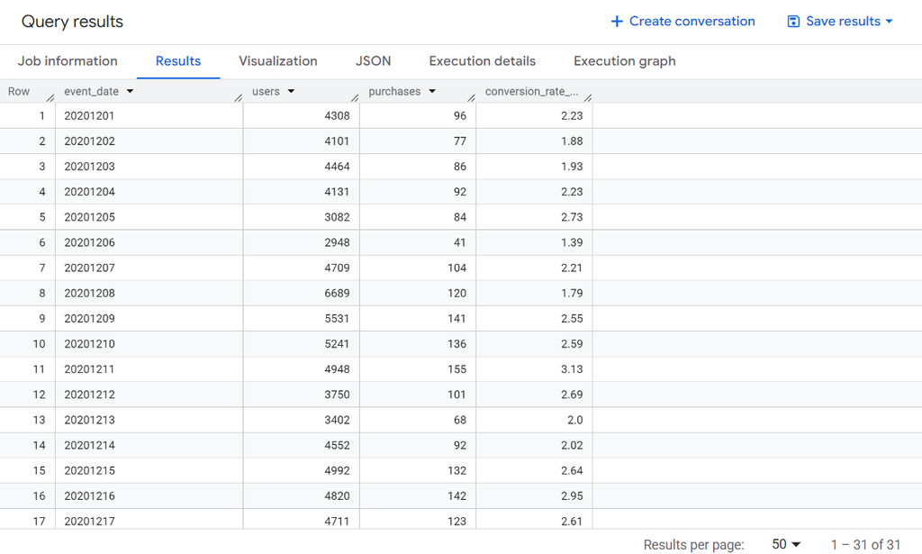

## Explanation

This query joins daily user counts with daily purchase counts to analyze user behavior and conversions over time. A LEFT JOIN is used to ensure that days without purchases are still included, and a conversion rate is calculated for each day.

# Query 8：Window Functions + QUALIFY: Top 3 Events per Day

WITH daily_event_counts AS (  
SELECT  
event_date,  
event_name,  
COUNT(*) AS events  
FROM `bigquery-public-data.ga4_obfuscated_sample_ecommerce.events_*`  
WHERE _TABLE_SUFFIX BETWEEN ‘20201201’ AND ‘20201207’  
GROUP BY event_date, event_name  
)  
SELECT  
event_date,  
event_name,  
events,  
RANK() OVER (PARTITION BY event_date ORDER BY events DESC) AS rnk  
FROM daily_event_counts  
QUALIFY rnk <= 3  
ORDER BY event_date, rnk;

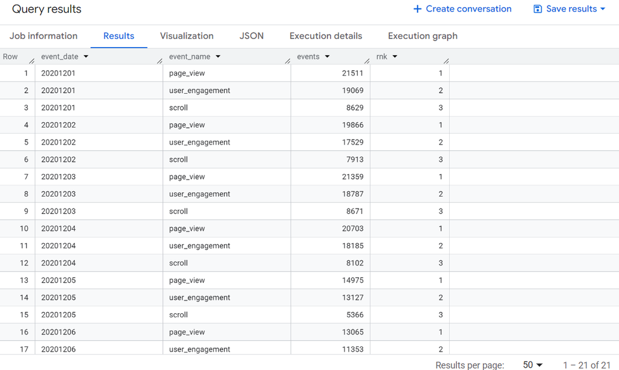

## Explanation

This query applies a window function to rank event types by frequency for each day. The `QUALIFY` clause is then used to filter the results, keeping only the top three most frequent events per day.

# Query 9：Window Function — Rolling 7-Day Average

WITH daily_purchases AS (  
SELECT  
PARSE_DATE(‘%Y%m%d’, event_date) AS dt,  
COUNT(*) AS purchases  
FROM `bigquery-public-data.ga4_obfuscated_sample_ecommerce.events_*`  
WHERE event_name = ‘purchase’  
AND _TABLE_SUFFIX BETWEEN ‘20201201’ AND ‘20201231’  
GROUP BY dt  
)  
SELECT  
dt,  
purchases,  
AVG(purchases) OVER (  
ORDER BY dt  
ROWS BETWEEN 6 PRECEDING AND CURRENT ROW  
) AS purchases_7d_avg  
FROM daily_purchases  
ORDER BY dt;

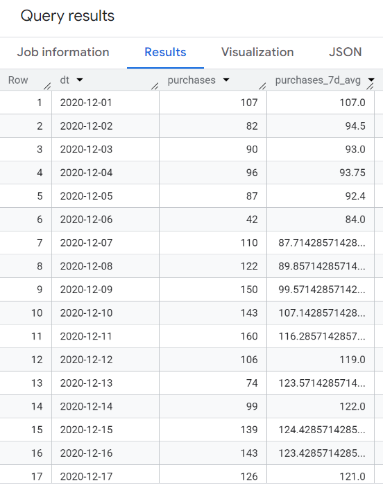

## Explanation

This query calculates a rolling seven-day average of daily purchase counts using a window function. The rolling average helps smooth daily fluctuations and highlights short-term trends in purchasing activity.

# Query 10：Approximate Functions: Approximate Distinct Users

SELECT  
event_name,  
APPROX_COUNT_DISTINCT(user_pseudo_id) AS approx_users  
FROM `bigquery-public-data.ga4_obfuscated_sample_ecommerce.events_*`  
WHERE _TABLE_SUFFIX BETWEEN ‘20201201’ AND ‘20201231’  
GROUP BY event_name  
ORDER BY approx_users DESC  
LIMIT 15;

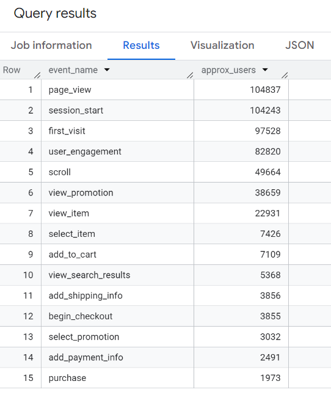

## Explanation

This query uses `APPROX_COUNT_DISTINCT` to estimate the number of unique users for each event type. Approximate functions improve performance on large datasets while still providing results that are close enough for high-level analysis.